# Safety Power Settings \& Recommender for Vaping Devices

by PozyPakya  
2015

## Introduction

This application was designed for user as a safe guideline for setting a single coil cartomizers especially for a novice vapors who might not familiar with Ohm's Law to understand how ohms and voltage can affect one's vape experience.

The application provide Safe Vaping Power chart which can be download in Excel format

The application do not promote for the user who are below 18+ years.

Copyright (c) 2015 PozyPakya

THE SOFTWARE IS PROVIDED "AS IS", WITHOUT WARRANTY OF ANY KIND, EXPRESS OR IMPLIED, INCLUDING BUT NOT LIMITED TO THE WARRANTIES OF MERCHANTABILITY, FITNESS FOR A PARTICULAR PURPOSE AND NONINFRINGEMENT. IN NO EVENT SHALL THE AUTHORS OR COPYRIGHT HOLDERS BE LIABLE FOR ANY CLAIM, DAMAGES OR OTHER LIABILITY, WHETHER IN AN ACTION OF CONTRACT, TORT OR OTHERWISE, ARISING FROM, OUT OF OR IN CONNECTION WITH THE SOFTWARE OR THE USE OR OTHER DEALINGS IN THE SOFTWARE.

## System requirement

The web application can be access from URL below :-

https://pozypakya.shinyapps.io/apps

# Compatible Browser

https://www.google.com/chrome/browser/desktop/  
http://www.opera.com/computer/windows  
https://www.mozilla.org/en-US/firefox/new/

## Slider - Main Interface

[figure not shown]

## Slider - Voltage and Ohms

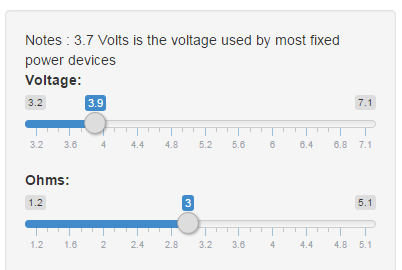

You can slide and change between the value for desired value.

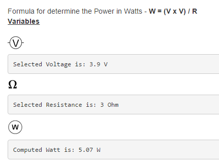

The value will automatically change if the slider above moves. Computed watt is the output.

## Recommendation

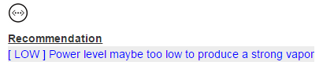

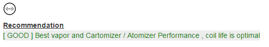

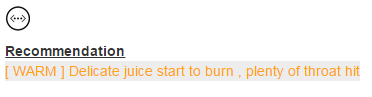

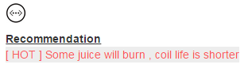

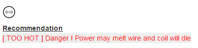

## vaping Power Chart

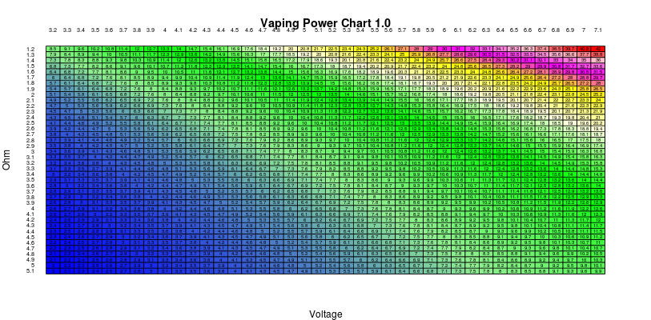

## Battery Safety Info

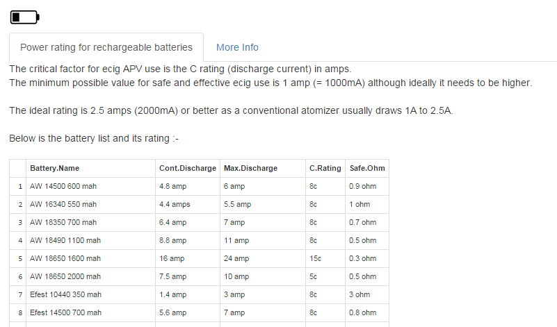

Please refer to battery safety information [here](http://s3.amazonaws.com/csvpastebin/uploads/d019eb968e1393af1716160e317682bf/batteryperformance.csv).The recommended safety OHM provided .

## Knowledge Based

[figure not shown]

[figure not shown]

[figure not shown]

[figure not shown]

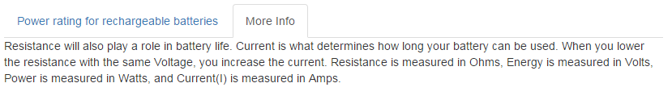

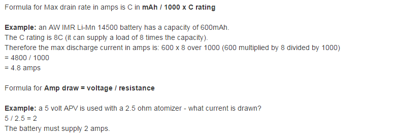

## Reference

http://blog.v-ecigs.com/2014/03/what-voltagewattage-should-i-vape-at.html  
http://www.tasteyourjuice.com/wordpress/volts-vs-ohms/  
http://vapeordie.com/vape/voltage-wattage-chart/  
http://www.vapertrain.com/page/utvvb  
https://www.e-cigarette-forum.com/forum/threads/e-liquid-nicotine-consumption-table-vaping-method.344166/

## GitHub

https://github.com/pozypakya/DevDataProducts

## Thank You

Developing Data Products Your Reproducible Pitch Presentation

OK, you've made your shiny app, now it's time to make your pitch. You get 5 slides (inclusive of the title slide) to pitch a your app. You're going to create a web page using Slidify or Rstudio Presenter with an html5 slide deck.

Here's what you need :-

5 slides to pitch our idea done in Slidify or Rstudio Presenter Your presentation pushed to github or Rpubs A link to your github or Rpubs presentation pasted into the text box below Your presentation must satisfy the following

It must be done in Slidify or Rstudio Presenter

It must be 5 pages

It must be hosted on github or Rpubs

It must contained some embedded R code that gets run when slidifying the document